# FightMND_QualityResearch

GNtem2

15/12/2021

## R Markdown

This is a pubmed search using the terms MND and randomised control trial. The search period is from 2011 to 2021.

## Impact factor journals

Hi impact factor journals is defined by the following journals: Lancet|Neurology|N Engl J Med| JAMA|Ann Neurol|Neurology|Nature|Brain

## Plot using grammar of graphics - ggplot

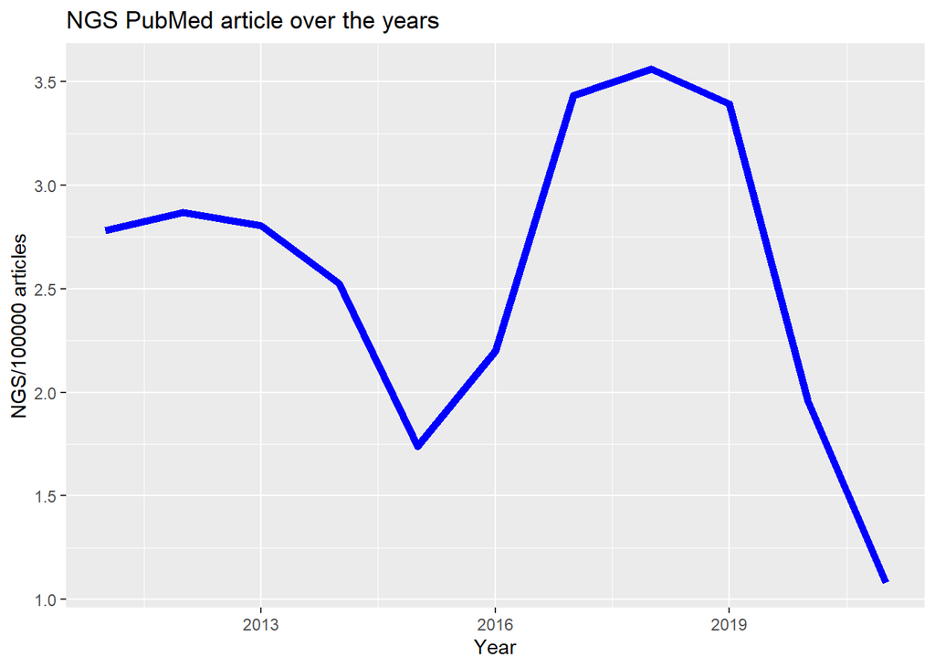

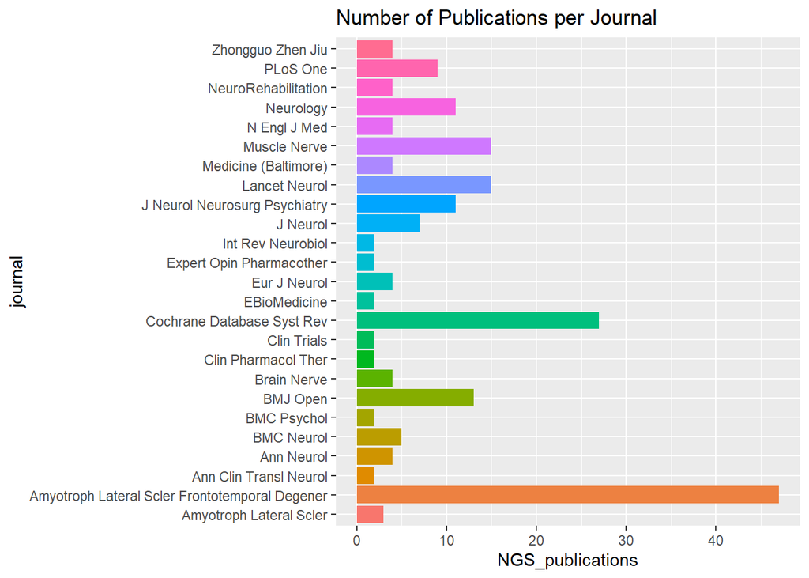

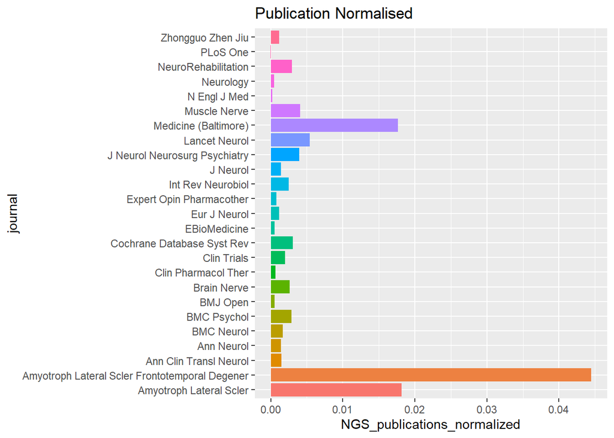

## Plot wordcloud

In this section we plot wordcloud from high and low impact factor journals. The word is analysed as unigram.

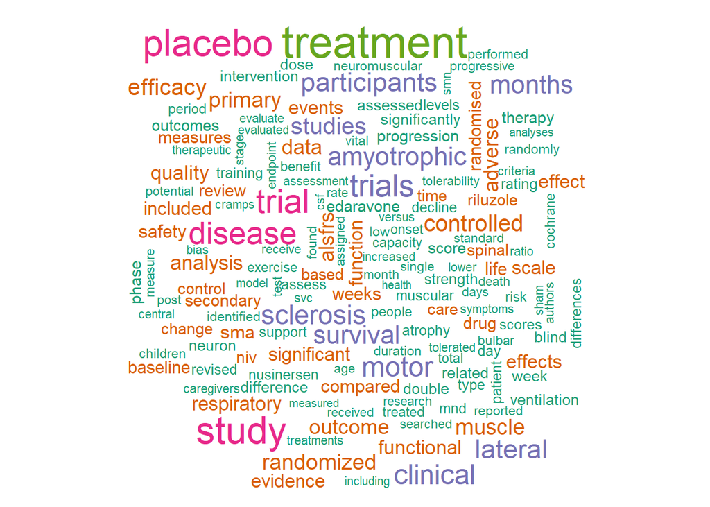

## Compare sentiment wordcloud from unigram

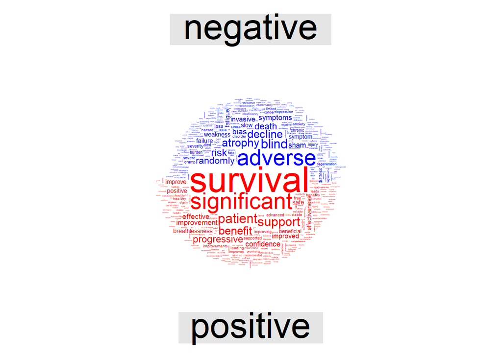

## High impact factor journals wordcloud

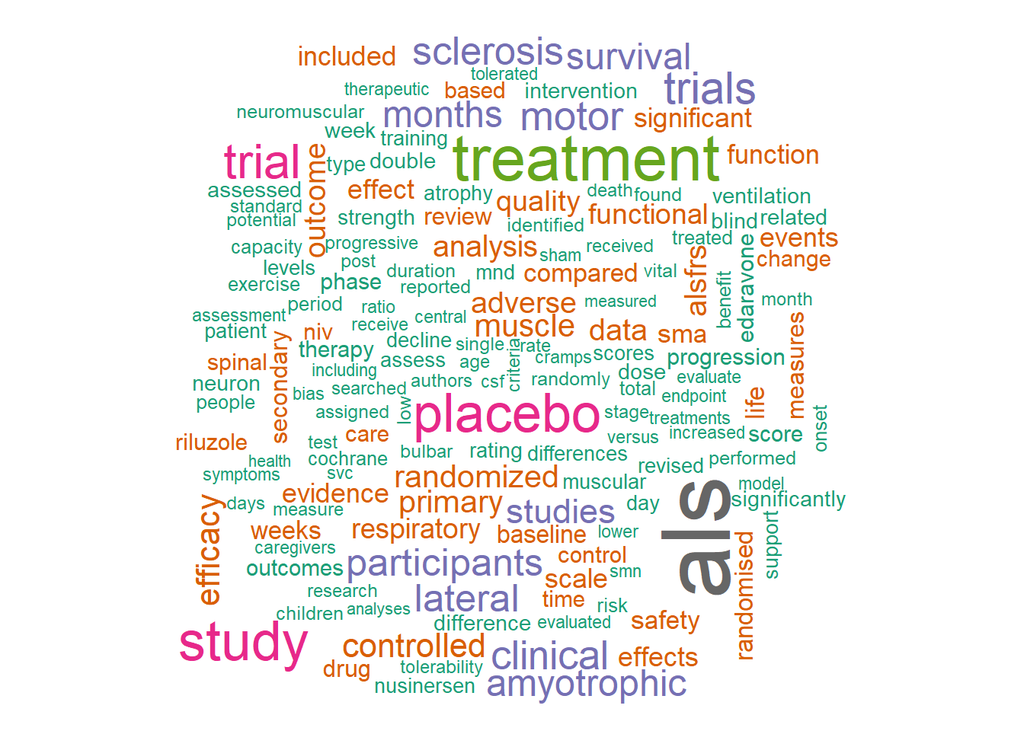

## Low impact factor General Journals wordcloud

Cochrane|Muscle|Respiration|BMC|PLoS|BMJ Open|Cochrane|Health Technol Assess|Respiration|Med J Aust|Eur J|Arq Neuropsiquiatr|Neurotherapeutics| J Med Genet| Am J Phys Med Rehabil|NeuroRehabilitation|Eur Respir J|Medicine (Baltimore)

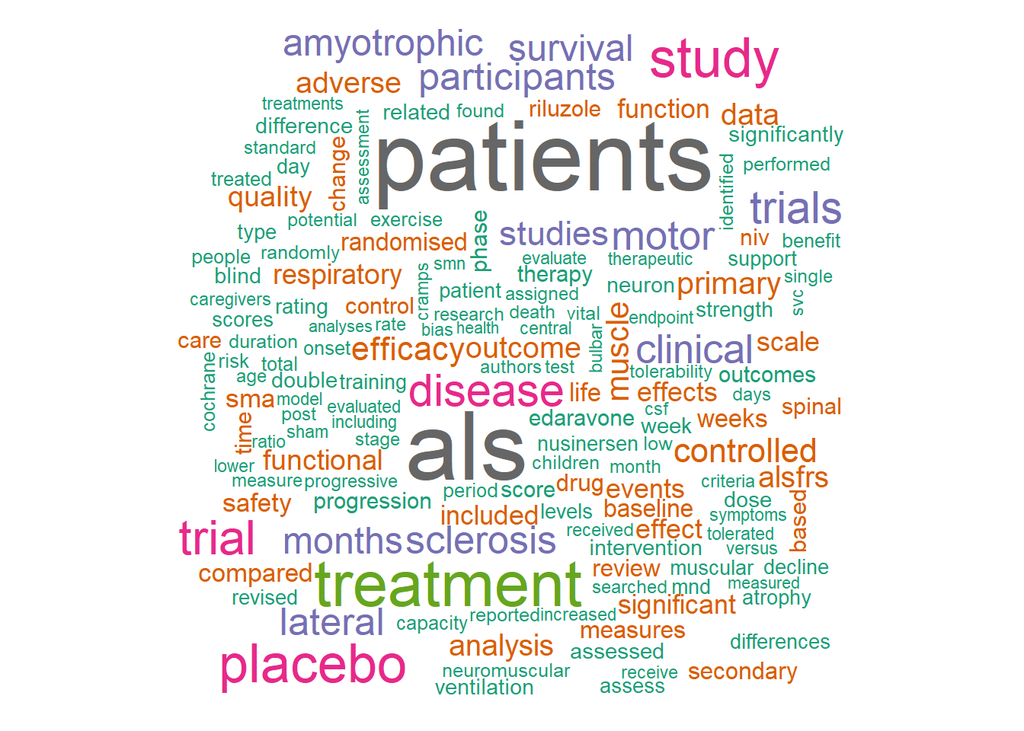

## Low impact factor Neuro Journals wordcloud

Amyotroph Lateral Scler|J Neurol|J Neurosci|Muscle|Arq Neuropsiquiatr|Neurotherapeutics|Neuron|Acta Neurol|Neuromuscul Disord|Parkinsonism Relat Disord|Parkinsons Dis

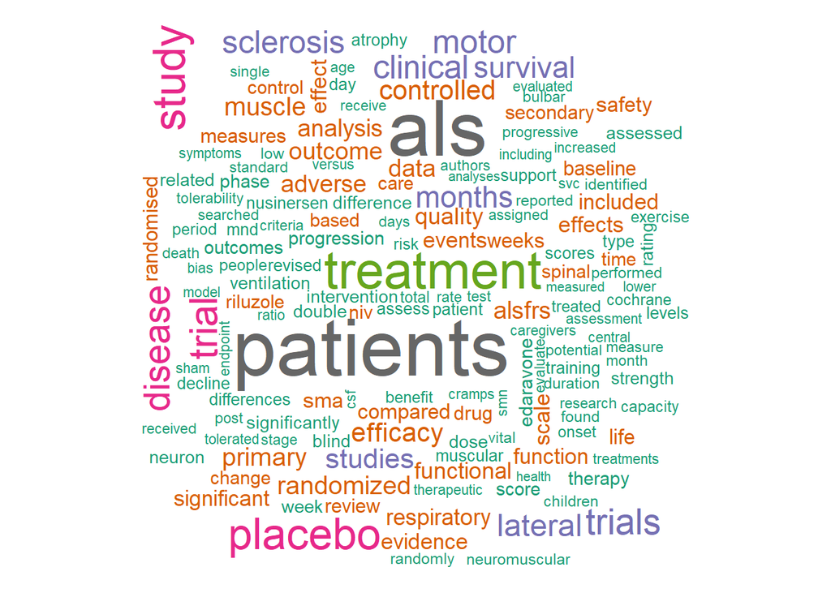

## Plot word relations - unigram

Community detection performed using walktrap. The algorithm determines community by short random walk. This information is used to provide color to the nodes. The size of the nodes is determined by number of adjacent nodes.

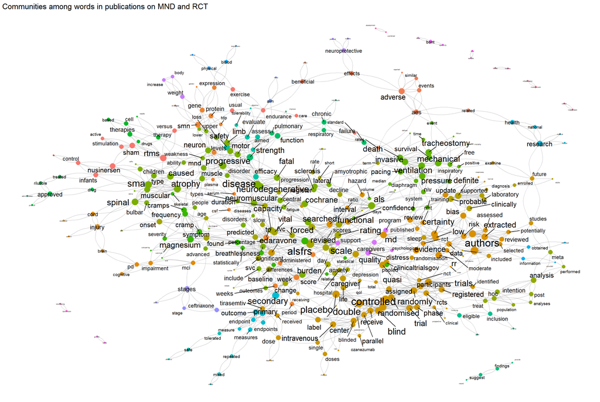

## Bigram - pair of words

```
## IGRAPH a4b795a DN-- 92 84 --
## + attr: name (v/c), n (e/n)
## + edges from a4b795a (vertex names):
##  [1]            ->             lateral    ->sclerosis
##  [3] amyotrophic->lateral                 ->months
##  [5] sclerosis  ->als                     ->patients
##  [7] adverse    ->events                  ->weeks
##  [9]            ->participants als        ->patients
## [11] double     ->blind        motor      ->neuron
## [13] rating     ->scale        functional ->rating
## [15] controlled ->trials       primary    ->outcome
## + ... omitted several edges
```

```
## # A tbl_graph: 92 nodes and 84 edges
## #
## # A directed multigraph with 16 components
## #
## # Node Data: 92 x 1 (active)
##   name
##   <chr>
## 1 ""
## 2 "lateral"
## 3 "amyotrophic"
## 4 "sclerosis"
## 5 "adverse"
## 6 "als"
## # ... with 86 more rows
## #
## # Edge Data: 84 x 3
##    from    to     n
##   <int> <int> <int>
## 1     1     1  2847
## 2     2     4   263
## 3     3     2   258
## # ... with 81 more rows
```

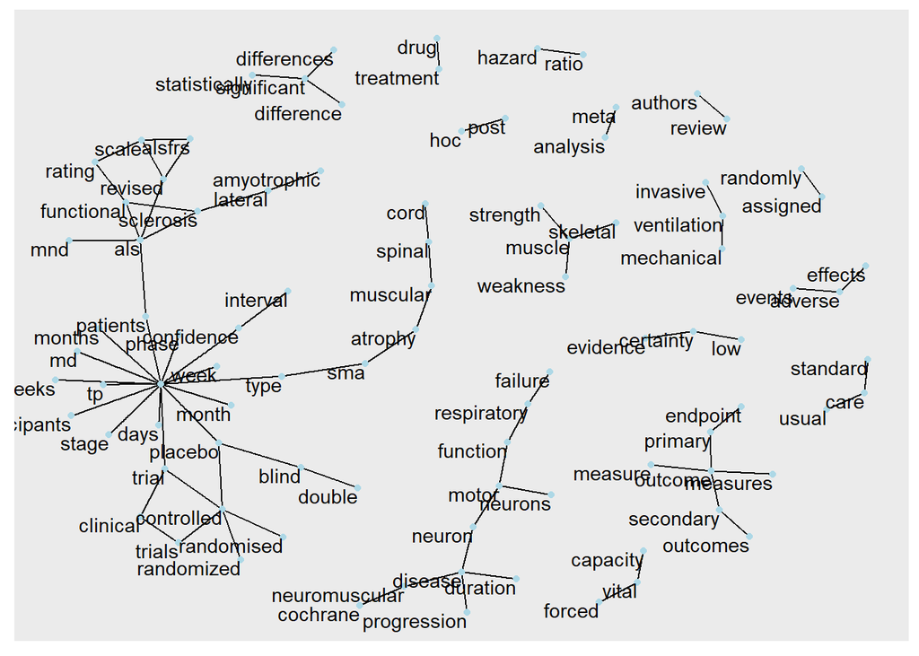